# Spatial Mapping of NASS Corn Yield Data

Ilyas Ustun

2017-07-14

This presentation can also be seen at [datacademy](https://www.datacademy.co)

# Spatial Mapping of NASS Corn Yield Data

I had prepared the necessary datasets of polygon and fips in order to do geographical mapping. These datasets will provide the backbone to carry out the mapping. Here, we will import data that contains the values to be mapped. I’ll use the corn yield data obtained from [USDA Nass](https://quickstats.nass.usda.gov/api) by using the api. I will refer to this dataset as *“nass data”* throughout the article. This dataset was already imported and saved as *nass_all_states.csv* on the hard drive.

If the polygon county data corresponding to *county.fips2* obtained from the *US Census Bureau* were to be found, using *county.fips2* would be more beneficial. Since it is more up-to-date than the *county.fips* present in the *maps* package. But for now, I will use the fips data from *maps* package, as it matches the polygon data, again provided by the same package.

## Preparing Nass Corn Yield Data

```r
library(stringr)
library(knitr)
library(tidyverse)
library(data.table)
library(DT)
library(RColorBrewer)

d = fread(str_c(files_dir, 'nass_all_states.csv'))
polygon_county = fread(str_c(files_dir, 'polygon_county.csv'))
polygon_state = fread(str_c(files_dir, 'polygon_state.csv'))

d[1:1000] %>% datatable()
d[, .N, .(state_alpha, state_name)] %>% datatable()
```

Nass data has the average yield of each county for each state. The states and the number of datapoints within each state is shown below. Since we don’t have polygin data for Hawaii, Hawaii will be taken out. Its number of entries is negligible anyway.

Now, we will go through some cleaning. Data points between 1980-2016 are taken for the analysis. At the end, only the necessary variables for the analyis will be retained.

```r
setnames(d, c('state_name', 'county_name', 'Value'), c('state', 'county', 'value') )
d = d[ year %in% seq(1980,2016) & agg_level_desc == 'COUNTY']

d = d %>% select(state, county, year, value)
x = d %>%
    select(state, county) %>%
    as.data.frame() %>%
    map_df(.f = str_to_lower) %>%
    map_df(.f = str_replace_all, pattern = '[[:punct:]]', replacement = '') %>%
    map_df(.f = str_replace_all, pattern = '[[:space:]]', replacement = '') %>%
    as.data.table()
d[, `:=`(state = x$state, county = x$county)]
d = d[county != 'othercombinedcounties']


# Check for suffixes
d_city = d[county %>% str_detect('city'), .SD]
d_city %>% datatable()
```

|  | state | county | year | value |
| --- | --- | --- | --- | --- |
| 1 | virginia | charlescity | 2016 | 153.6 |
| 2 | virginia | charlescity | 2015 | 176 |
| 3 | virginia | charlescity | 2014 | 157.3 |
| 4 | virginia | charlescity | 2013 | 172.8 |
| 5 | virginia | charlescity | 2012 | 111 |
| 6 | virginia | charlescity | 2011 | 110.2 |
| 7 | virginia | charlescity | 2010 | 49.4 |
| 8 | virginia | charlescity | 2009 | 115 |
| 9 | virginia | charlescity | 2008 | 75 |
| 10 | virginia | charlescity | 2007 | 114 |

[output cut: 162 more lines]

```r
d_borough = d[county %>% str_detect('borough'), .SD]
d_borough
```

```
## Empty data.table (0 rows) of 4 cols: state,county,year,value
```

```r
d_county = d[county %>% str_detect('county'), .SD]
d_county
```

```
## Empty data.table (0 rows) of 4 cols: state,county,year,value
```

```r
d_parish = d[county %>% str_detect('parish'), .SD]
d_parish
```

```
## Empty data.table (0 rows) of 4 cols: state,county,year,value
```

```r
d_muni = d[county %>% str_detect('municip'), .SD]
d_muni
```

```
## Empty data.table (0 rows) of 4 cols: state,county,year,value
```

```r
d_main = d[county %>% str_detect('main'), .SD]
d_main
```

```
## Empty data.table (0 rows) of 4 cols: state,county,year,value
```

```r
d_saint = d[county %>% str_detect('saint'), .SD]
d_saint %>% datatable()
```

|  | state | county | year | value |
| --- | --- | --- | --- | --- |
| 1 | alabama | saintclair | 1987 | 70.0 |
| 2 | alabama | saintclair | 1986 | 70.0 |
| 3 | alabama | saintclair | 1985 | 62.9 |
| 4 | alabama | saintclair | 1983 | 40.0 |
| 5 | alabama | saintclair | 1982 | 50.0 |
| 6 | arkansas | saintfrancis | 2015 | 165.7 |
| 7 | arkansas | saintfrancis | 2014 | 179.1 |
| 8 | arkansas | saintfrancis | 2013 | 172.4 |
| 9 | arkansas | saintfrancis | 2011 | 159.5 |
| 10 | arkansas | saintfrancis | 2010 | 160 |

[output cut: 89 more lines]

Nass data has been checked for various suffixes, and only “city” is present in the state of Virginia. However, there is also something new, compared to previous datasets of polygon and fips data. That is, in the previous cases “saint” prefixes were abbreviated as “st”. Here it is kept as “saint”.

In VA, only James City, and Charles City will keep their “city” suffixes, and all “saint”s will be converted to “st”.

```r
# Clean "saint"
d$county = d$county %>%
    str_replace_all(pattern = 'saint', 'st')

# Clean "city"
va = d[state %in% 'virginia', ][, row_id := .I]

va2 = va %>%
    select(state, county, row_id) %>%
    filter(state == 'virginia') %>%
    filter(county %in% c('jamescity', 'charlescity'))

va3 = va %>%
    select(state, county, row_id) %>%
    filter(state == 'virginia') %>%
    filter(!county %in% c('jamescity', 'charlescity')) %>%
    map_df(.f = str_replace_all, pattern = 'city', '') %>%
    rbind(va2) %>%
    arrange(as.integer(row_id)) %>%
    as.data.table()

d[state %in% 'virginia', county := va3$county]

# Get rid of duplicated records
d = d[!duplicated(d)]

d = d[!is.na(year)]

d = d[order(state, county, year)]
d[1:1000] %>% datatable()
```

|  | state | county | year | value |
| --- | --- | --- | --- | --- |
| 1 | alabama | autauga | 1980 | 20.8 |
| 2 | alabama | autauga | 1981 | 17.3 |
| 3 | alabama | autauga | 1982 | 59.1 |
| 4 | alabama | autauga | 1983 | 38.0 |
| 5 | alabama | autauga | 1984 | 41.2 |
| 6 | alabama | autauga | 1985 | 56.5 |
| 7 | alabama | autauga | 1986 | 38.5 |
| 8 | alabama | autauga | 1987 | 47.7 |
| 9 | alabama | autauga | 1988 | 20.0 |
| 10 | alabama | autauga | 1989 | 62.5 |

[output cut: 990 more lines]

Nass data is clean and ready to be combined with polygon and fips data.

```r
d = left_join(d, polygon_county) %>% as.data.table()
d[is.na(fips)] %>% datatable()
```

|  | state | county | year | value | long | lat | group | order | fips |
| --- | --- | --- | --- | --- | --- | --- | --- | --- | --- |
| 1 | southdakota | oglalalakota | 1980 | 83.3 |  |  |  |  |  |
| 2 | southdakota | oglalalakota | 1981 | 78 |  |  |  |  |  |
| 3 | southdakota | oglalalakota | 1982 | 52 |  |  |  |  |  |
| 4 | southdakota | oglalalakota | 1983 | 80 |  |  |  |  |  |
| 5 | southdakota | oglalalakota | 1984 | 75 |  |  |  |  |  |
| 6 | southdakota | oglalalakota | 1985 | 70 |  |  |  |  |  |
| 7 | southdakota | oglalalakota | 1986 | 69 |  |  |  |  |  |
| 8 | southdakota | oglalalakota | 1987 | 40 |  |  |  |  |  |
| 9 | southdakota | oglalalakota | 1988 | 47 |  |  |  |  |  |
| 10 | southdakota | oglalalakota | 1989 | 81 |  |  |  |  |  |

[output cut: 53 more lines]

```r
d[, `:=`(year = as.integer(year),
         value = as.numeric(value))]

d = na.omit(d)
```

All the counties now have their corresponding lat, long and fips data, except for two: Chesapeake, Virginia and Oglalalakota, South Dakota. I have no idea why these are not present in the *polygon_county* dataset, but that’s beyond me.

We will also calculate the mean yield for each year in each state. This will allow us to plot the average yield of states throughout the years.

```r
d_avg_state = d[, .(value_state = mean(value)), by = .(state, year)]
d_state = left_join(d_avg_state, polygon_state) %>% as.data.table()
d[1:1000] %>% datatable(caption = 'County Yield')
```

|  | state | county | year | value | long | lat | group | order | fips |
| --- | --- | --- | --- | --- | --- | --- | --- | --- | --- |
| 1 | alabama | autauga | 1980 | 20.8 | -86.5051651000977 | 32.3491973876953 | 1 | 1 | 1001 |
| 2 | alabama | autauga | 1980 | 20.8 | -86.533821105957 | 32.3549270629883 | 1 | 2 | 1001 |
| 3 | alabama | autauga | 1980 | 20.8 | -86.5452728271484 | 32.3663864135742 | 1 | 3 | 1001 |
| 4 | alabama | autauga | 1980 | 20.8 | -86.5567321777344 | 32.3778457641602 | 1 | 4 | 1001 |
| 5 | alabama | autauga | 1980 | 20.8 | -86.5796585083008 | 32.3835716247559 | 1 | 5 | 1001 |
| 6 | alabama | autauga | 1980 | 20.8 | -86.5911102294922 | 32.3778457641602 | 1 | 6 | 1001 |
| 7 | alabama | autauga | 1980 | 20.8 | -86.6140289306641 | 32.3893051147461 | 1 | 7 | 1001 |
| 8 | alabama | autauga | 1980 | 20.8 | -86.619758605957 | 32.4064903259277 | 1 | 8 | 1001 |
| 9 | alabama | autauga | 1980 | 20.8 | -86.62548828125 | 32.4179534912109 | 1 | 9 | 1001 |
| 10 | alabama | autauga | 1980 | 20.8 | -86.6369476318359 | 32.4179534912109 | 1 | 10 | 1001 |

[output cut: 990 more lines]

```r
d_state[1:1000] %>% datatable(caption = 'State Yield')
```

|  | state | year | value_state | long | lat | group | order | county |
| --- | --- | --- | --- | --- | --- | --- | --- | --- |
| 1 | alabama | 1980 | 30.0575276752768 | -87.4620056152344 | 30.3896808624268 | 1 | 1 |  |
| 2 | alabama | 1980 | 30.0575276752768 | -87.4849319458008 | 30.3724918365479 | 1 | 2 |  |
| 3 | alabama | 1980 | 30.0575276752768 | -87.525032043457 | 30.3724918365479 | 1 | 3 |  |
| 4 | alabama | 1980 | 30.0575276752768 | -87.53076171875 | 30.3323860168457 | 1 | 4 |  |
| 5 | alabama | 1980 | 30.0575276752768 | -87.5708694458008 | 30.3266544342041 | 1 | 5 |  |
| 6 | alabama | 1980 | 30.0575276752768 | -87.5880584716797 | 30.3266544342041 | 1 | 6 |  |
| 7 | alabama | 1980 | 30.0575276752768 | -87.5937881469727 | 30.3094673156738 | 1 | 7 |  |
| 8 | alabama | 1980 | 30.0575276752768 | -87.5937881469727 | 30.286548614502 | 1 | 8 |  |
| 9 | alabama | 1980 | 30.0575276752768 | -87.6740036010742 | 30.275089263916 | 1 | 9 |  |
| 10 | alabama | 1980 | 30.0575276752768 | -87.8115158081055 | 30.2579021453857 | 1 | 10 |  |

[output cut: 990 more lines]

Now we have two datasets: **d**, which is the county yield data, and **d_state** which is the state yield data, and are ready for doing the thing that we wanted to do all along: *geographical mapping*.

## Mapping State Level Data

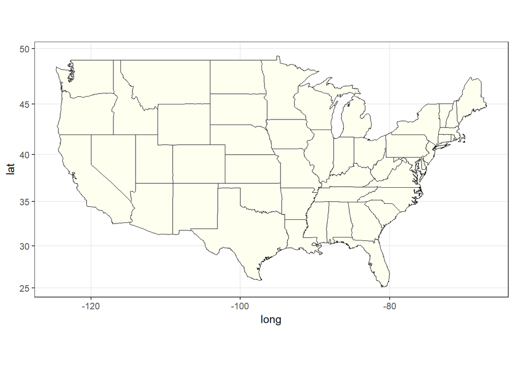

The plain state map of USA

```r
ggplot(data = polygon_state, mapping = aes(x = long, y = lat, group = group)) +
    geom_polygon(fill = 'ivory1', color = "black", size = 0.1) +
    coord_map('mercator') +
    theme_bw()
```

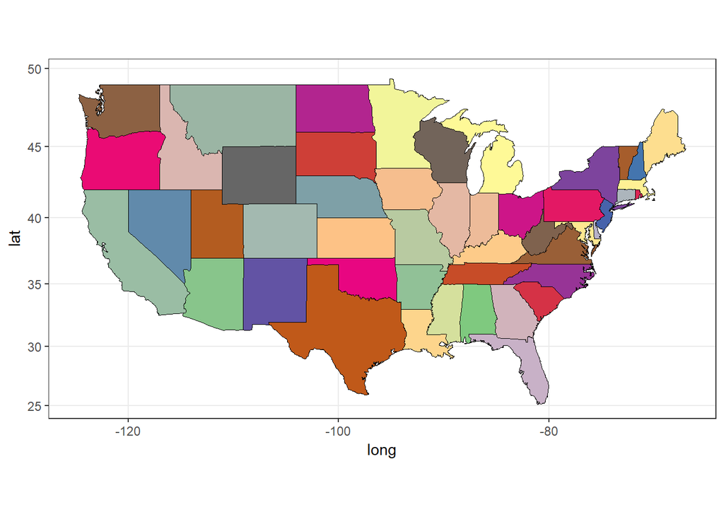

The colored state map of USA

```r
numdata = polygon_state[, .(unique(state))][,.N]
pal = brewer.pal(name = 'Accent', n = 8)
colors = colorRampPalette(pal)
colors = colors(numdata)

ggplot(data = polygon_state, mapping = aes(x = long, y = lat, group = group)) +
    geom_polygon(aes(fill = state), color = "black", size = 0.1) +
    scale_fill_manual(values = colors, guide = FALSE) +
    coord_map('mercator') +
    theme_bw()
```

### Labelling the States

When we produce a spatial plot, we might need to show the names of places. Here we will label the states on the state map, and show them at their corresponding state centers. For this purpose, we will make use of the *center_state* data we computed before.

Here since some states have peninsulas, and/or islands we will first have to get their main parts. Otherwise, the names will be plotted on each of these separate areas, which will clutter the map. It will already be cluttered in the Northeast part of US where there are many small states neighbouring each other.

```r
center_state = fread(str_c(files_dir, 'center_state.csv'))
center_state %>% datatable()
```

|  | state | county | group | long | lat |
| --- | --- | --- | --- | --- | --- |
| 1 | alabama |  | 1 | -86.8598037647694 | 31.6705498726991 |
| 2 | arizona |  | 2 | -113.276485650887 | 34.5432540430521 |
| 3 | arkansas |  | 3 | -91.285141554029 | 34.641457729724 |
| 4 | california |  | 4 | -120.628418068592 | 36.7485733021696 |
| 5 | colorado |  | 5 | -105.075092656957 | 38.6111652426105 |
| 6 | connecticut |  | 6 | -72.7209092674678 | 41.3841221000898 |
| 7 | delaware |  | 7 | -75.3815231617054 | 39.09394024001 |
| 8 | districtofcolumbia |  | 8 | -77.0622416445397 | 38.9044204421632 |
| 9 | florida |  | 9 | -83.3285501334347 | 28.7490640017626 |
| 10 | georgia |  | 10 | -82.5891693798366 | 32.2236252774515 |

[output cut: 53 more lines]

Labelling the states using state_center data

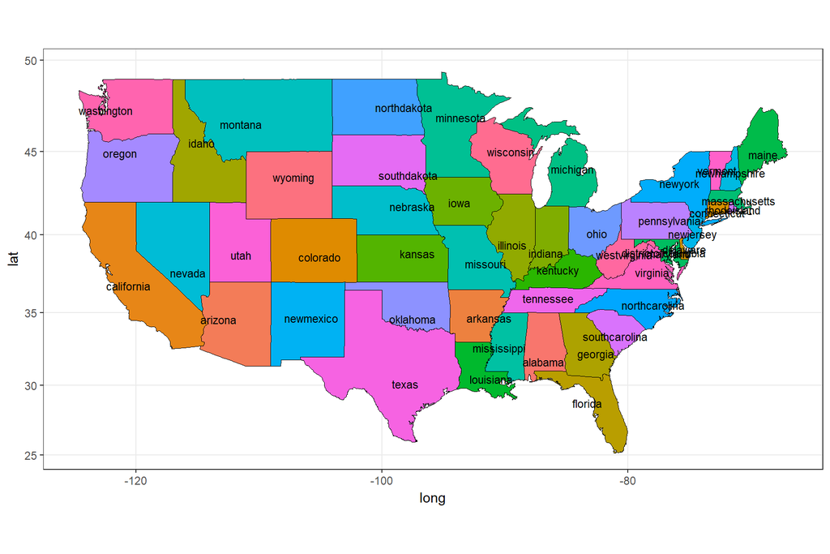

Labelling the states using state_center data

```r
center_main = center_state[state %in% c('newyork','northcarolina', 'virginia', 'washington', 'massachusetts') & county == 'main' |
                 state == 'michigan' & county == 'south']
center_state = rbind(center_state[county %in% ''], center_main)
ggplot(data = polygon_state, mapping = aes(x = long, y = lat, group = group)) +
    geom_polygon(aes(fill = state), color = "black", size = 0.1) +
    geom_text(data = center_state, aes(x = long, y = lat, label = state), size = 3) +
    scale_fill_discrete(guide = FALSE) +
    coord_map('mercator') +
    theme_bw()
```

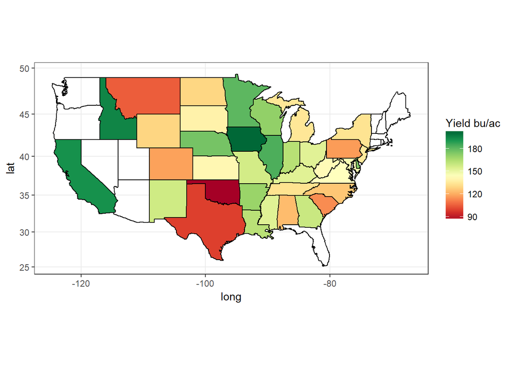

State average corn yield in bushels per acre (bu/ac) for the year 2016

```r
ggplot(data = d_state[year == 2016], mapping = aes(x = long, y = lat, group = group)) +
    geom_polygon(aes(fill = value_state), color = "black", size = 0.1) +
    geom_polygon(data = polygon_state, col = 'black', fill = NA) +
    scale_fill_gradientn(name = 'Yield bu/ac', colors = brewer.pal(n = 11, name = 'RdYlGn')) +
    coord_map('mercator') +
    theme_bw()
```

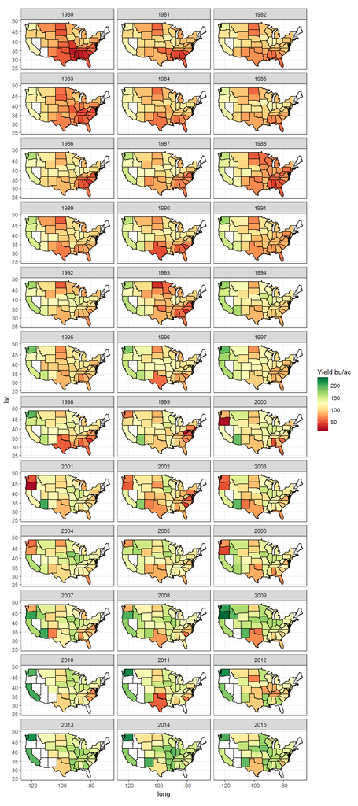

State average corn yield, years 1980 - 2015

```r
ggplot(data = d_state[year %between% c(1980, 2015)], mapping = aes(x = long, y = lat, group = group)) +
    geom_polygon(aes(fill = value_state), color = "black", size = 0.1) +
    geom_polygon(data = polygon_state, col = 'black', fill = NA) +
    scale_fill_gradientn(name = 'Yield bu/ac',
        colors = brewer.pal(n = 11, name = 'RdYlGn')) +
    facet_wrap(~year, ncol = 3) +
    coord_map('mercator') +
    theme_bw()
```

Mapping state average corn yield can give an overall idea of the production. However, it can also be grossly misleading as even if there is only 1 county having yield data, it will seem like thw whole state is producing corn. Instead checking the county yield data can be more useful.

## Mapping County Level Data

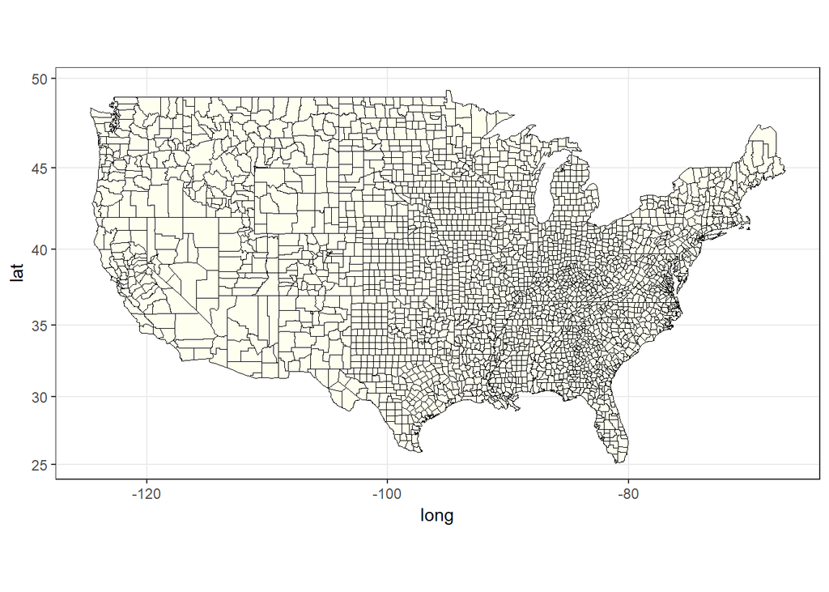

The plain county map of USA

```r
ggplot(data = polygon_county, mapping = aes(x = long, y = lat, group = group)) +
    geom_polygon(fill = 'ivory1', color = "black", size = 0.05) +
    coord_map('mercator') +
    theme_bw()
```

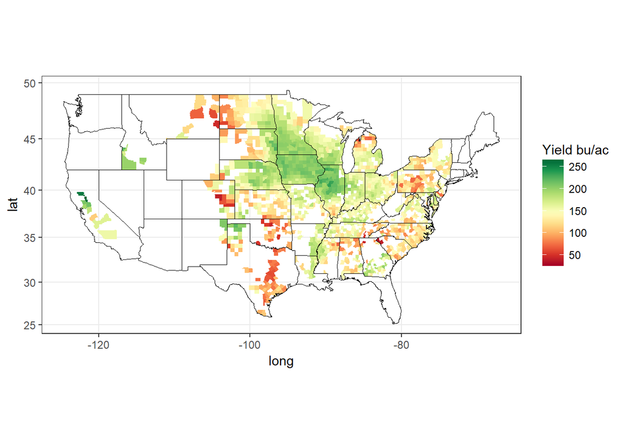

County yield map for the year 2016

```r
ggplot(data = d[year == 2016], mapping = aes(x = long, y = lat, group = group)) +
    geom_polygon(aes(fill = value), color = NA, size = 0.1) +
    geom_polygon(data = polygon_state, col = 'black', fill = NA, size = 0.1) +
    scale_fill_gradientn(name = 'Yield bu/ac',
        colors = brewer.pal(n = 11, name = 'RdYlGn')) +
    coord_map('mercator') +
    theme_bw()
```

As can be seen, some states have only a few counties of corn yield data, which could not be seen with state level yield maps.

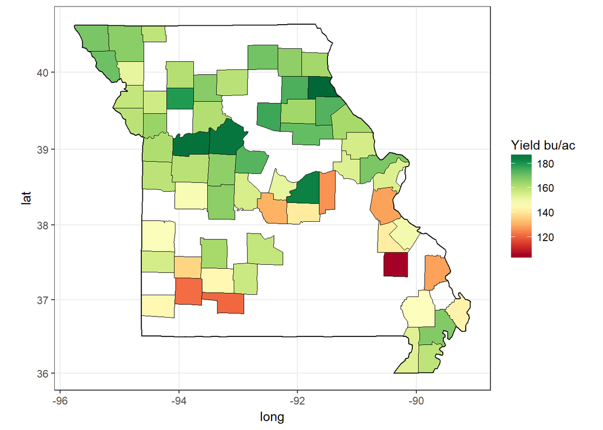

Corn yield of counties in a single state, Missouri, for 2016

```r
ggplot(data = d[year == 2016 & state == 'missouri'],
    mapping = aes(x = long, y = lat, group = group)) +
    geom_polygon(aes(fill = value), color = "black", size = 0.1) +
    geom_polygon(data = polygon_state[state == 'missouri'], col = 'black', fill = NA) +
    scale_fill_gradientn(name = 'Yield bu/ac',
        colors = brewer.pal(n = 11, name = 'RdYlGn')) +
    coord_map('mercator') +
    theme_bw()
```

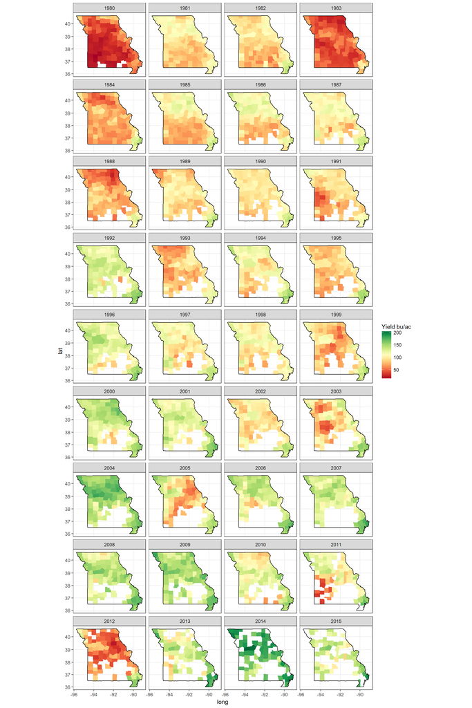

Corn yield of counties in a single state, Missouri, between 1980 - 2015

```r
ggplot(data = d[year %between% c(1980, 2015) & state == 'missouri'], mapping = aes(x = long, y = lat, group = group)) +
    geom_polygon(aes(fill = value), color = NA, size = 0.1) +
    geom_polygon(data = polygon_state[state == 'missouri'], col = 'black', fill = NA) +
    scale_fill_gradientn(name = 'Yield bu/ac',
        colors = brewer.pal(n = 11, name = 'RdYlGn')) +
    coord_map('mercator') +
    facet_wrap(~year, ncol = 4) +
    theme_bw()
```

## Maps of a Region: MidWest

We have mapped all states county yield data, and also single state county yield data. As can be guessed we can also map several states. It can be seen that the Mid-West has generally the highest average yield among all states. So let’s only analyze the Mid-West.

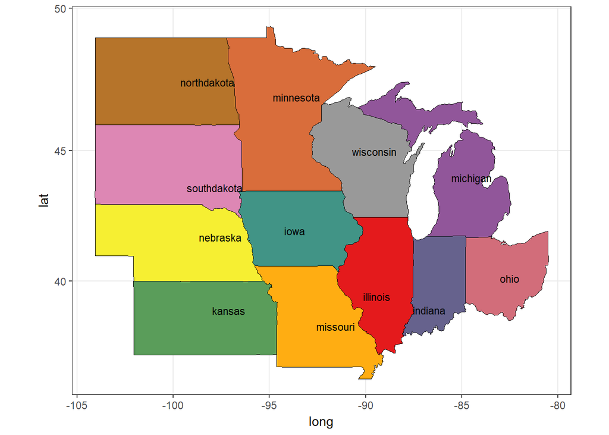

US Mid-West States

```r
midwest = c('northdakota', 'southdakota', 'nebraska', 'kansas', 'missouri', 'illinois',
            'iowa', 'minnesota', 'wisconsin', 'indiana', 'michigan', 'ohio')

numdata = length(midwest)
pal = brewer.pal(name = 'Set1', n =11)
colors = colorRampPalette(pal)
colors = colors(numdata)

ggplot(data = polygon_state[state %in% midwest],
       mapping = aes(x = long, y = lat, group = group)) +
    geom_polygon(aes(fill = state), color = "black", size = 0.1) +
    geom_text(data = center_state[state %in% midwest],
              aes(x = long, y = lat, label = state), size = 3) +
    scale_fill_manual(values = colors, guide = FALSE) +
    coord_map('mercator') +
    theme_bw()
```

So these are the states that constitute the Mid-West USA. We have made use of center_state data we computed before.

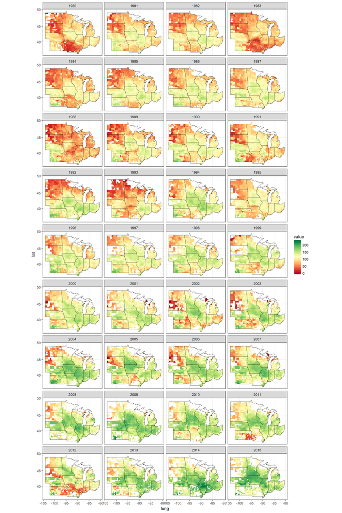

Corn yield of counties in the MidWest, between 1980 - 2015

```r
ggplot(data = d[year %between% c(1980, 2015) & state %in% midwest],
       mapping = aes(x = long, y = lat, group = group)) +
    geom_polygon(aes(fill = value), color = NA, size = 0.1) +
    geom_polygon(data = polygon_state[state %in% midwest],
                 col = 'black', fill = NA, size = 0.1) +
    scale_fill_gradientn(colors = brewer.pal(n = 11, name = 'RdYlGn')) +
    coord_map('mercator') +
    facet_wrap(~year, ncol = 4) +
    theme_bw()
```

So that’s it. We have achieved to succesfully import, clean and join the polygon, fips, and the nass datasets. Then, we have used these datasets to produce various geographical maps. The visualization of such spatial data can provide great insights into understanding and developing models.